# Project_Report_Final

```python
import wrds
from fredapi import Fred
import time
import matplotlib.pyplot as plt

import pandas as pd
import numpy as np
time.ctime()
```

```
'Tue Dec  5 09:18:29 2023'
```

```python
cd
```

```
C:\Users\Aadiv Das
```

## WRDS DATA

```python
conn=wrds.Connection()
```

```
Enter your WRDS username [Aadiv Das]:rishavmondal1
Enter your password:········
WRDS recommends setting up a .pgpass file.
Create .pgpass file now [y/n]?: y
Created .pgpass file successfully.
You can create this file yourself at any time with the create_pgpass_file() function.
Loading library list...
Done
```

### Visualising the data

```python
Nat_Comm_Bank = conn.raw_sql('''select cik, gvkey, datadate, conm, revt, ni from comp.funda
                        where sich=6020 and datadate>='01/01/1990' and datadate<='12/31/2023'
                        and  datafmt = 'STD' and consol = 'C'and indfmt = 'INDL'
                        ''', date_cols=['datadate'])
Nat_Comm_Bank['year']=pd.DatetimeIndex(Nat_Comm_Bank['datadate']).year
Nat_Comm_Bank['month']=pd.DatetimeIndex(Nat_Comm_Bank['datadate']).month
```

```python
Nat_Comm_Bank
```

|  | cik | gvkey | datadate | conm | revt | ni | year | month |
| --- | --- | --- | --- | --- | --- | --- | --- | --- |
| 0 | 0000763901 | 002002 | 2009-12-31 | POPULAR INC | 2751.498 | -573.919 | 2009 | 12 |
| 1 | 0000763901 | 002002 | 2010-12-31 | POPULAR INC | 2595.637 | 137.401 | 2010 | 12 |
| 2 | 0000763901 | 002002 | 2011-12-31 | POPULAR INC | 2497.778 | 151.325 | 2011 | 12 |
| 3 | 0000763901 | 002002 | 2012-12-31 | POPULAR INC | 2218.047 | 245.275 | 2012 | 12 |
| 4 | 0000763901 | 002002 | 2013-12-31 | POPULAR INC | 2128.709 | 599.327 | 2013 | 12 |
| ... | ... | ... | ... | ... | ... | ... | ... | ... |
| 10221 | 0000931061 | 268025 | 2015-12-31 | ABBEY NATL TREASURY SVCS PLC | 2745.000 | 392.000 | 2015 | 12 |
| 10222 | 0000931061 | 268025 | 2016-12-31 | ABBEY NATL TREASURY SVCS PLC | 1573.000 | 223.000 | 2016 | 12 |
| 10223 | 0000931061 | 268025 | 2017-12-31 | ABBEY NATL TREASURY SVCS PLC | 1189.000 | 179.000 | 2017 | 12 |
| 10224 | 0000931061 | 268025 | 2018-12-31 | ABBEY NATL TREASURY SVCS PLC | 21.029 | 24.470 | 2018 | 12 |
| 10225 | 0000931061 | 268025 | 2019-12-31 | ABBEY NATL TREASURY SVCS PLC | 88.337 | -8.873 | 2019 | 12 |

10226 rows × 8 columns

```python
Nat_Comm_Bank.info()
```

```
<class 'pandas.core.frame.DataFrame'>
RangeIndex: 10226 entries, 0 to 10225
Data columns (total 8 columns):
 #   Column    Non-Null Count  Dtype
---  ------    --------------  -----
 0   cik       9825 non-null   object
 1   gvkey     10226 non-null  object
 2   datadate  10226 non-null  datetime64[ns]
 3   conm      10226 non-null  object
 4   revt      10214 non-null  float64
 5   ni        10220 non-null  float64
 6   year      10226 non-null  int64
 7   month     10226 non-null  int64
dtypes: datetime64[ns](1), float64(2), int64(2), object(3)
memory usage: 639.2+ KB
```

### Nat_Comm_Bank is the WRDS data

## FRED DATA

```python
mykey='f5d244832c04e7d91938cc305d3a429d'
```

```python
fred = Fred(api_key=mykey)
```

```python
Exstng_Home_Sls = 'EXHOSLUSM495S'#Existing home sales
Reces_Prob='RECPROUSM156N' #Recession PRobability
Fed_Funds = 'DFF' #Federal Funds Effective Rate
```

```python
Hme_sls = fred.get_series(Exstng_Home_Sls, obsevation_start = '1990-01-01')
FF_IR=fred.get_series(Fed_Funds,observation_start='1990-01-01')
R_Prob=fred.get_series(Reces_Prob, observation_start='1990-01-01')
```

### Rishav

```python
Hme_sls
```

```
2022-09-01          NaN
2022-10-01    4440000.0
2022-11-01    4120000.0
2022-12-01    4030000.0
2023-01-01    4000000.0
2023-02-01    4550000.0
2023-03-01    4430000.0
2023-04-01    4290000.0
2023-05-01    4300000.0
2023-06-01    4160000.0
2023-07-01    4070000.0
2023-08-01    4040000.0
2023-09-01    3950000.0
2023-10-01    3790000.0
dtype: float64
```

### Dhruv

```python
FF_IR
```

```
1990-01-01    7.97
1990-01-02    8.54
1990-01-03    8.37
1990-01-04    8.29
1990-01-05    8.20
              ...
2023-11-27    5.33
2023-11-28    5.33
2023-11-29    5.33
2023-11-30    5.33
2023-12-01    5.33
Length: 12388, dtype: float64
```

### Shiny

```python
R_Prob
```

```
1990-01-01    0.26
1990-02-01    0.10
1990-03-01    0.36
1990-04-01    1.16
1990-05-01    1.60
              ...
2023-06-01    0.38
2023-07-01    0.10
2023-08-01    0.14
2023-09-01    0.36
2023-10-01    2.22
Length: 406, dtype: float64
```

### Adjusting the Dataset

```python
#resetting the index
Hme_sls = Hme_sls.reset_index()
FF_IR = FF_IR.reset_index()
R_Prob = R_Prob.reset_index()
```

```python
#giving the appropriate names to the column
Hme_sls = Hme_sls.rename(columns={0:'Housing Units Sold', 'index':'date'})
R_Prob=R_Prob.rename(columns={0:'Recession probability','index':'date'})
FF_IR=FF_IR.rename(columns={0:'Federal Funds','index':'date'})
```

#### Rishav

```python
Hme_sls
```

|  | date | Housing Units Sold |
| --- | --- | --- |
| 0 | 2022-09-01 | NaN |
| 1 | 2022-10-01 | 4440000.0 |
| 2 | 2022-11-01 | 4120000.0 |
| 3 | 2022-12-01 | 4030000.0 |
| 4 | 2023-01-01 | 4000000.0 |
| 5 | 2023-02-01 | 4550000.0 |
| 6 | 2023-03-01 | 4430000.0 |
| 7 | 2023-04-01 | 4290000.0 |
| 8 | 2023-05-01 | 4300000.0 |
| 9 | 2023-06-01 | 4160000.0 |
| 10 | 2023-07-01 | 4070000.0 |
| 11 | 2023-08-01 | 4040000.0 |
| 12 | 2023-09-01 | 3950000.0 |
| 13 | 2023-10-01 | 3790000.0 |

#### Dhruv

```python
FF_IR
```

|  | date | Federal Funds |
| --- | --- | --- |
| 0 | 1990-01-01 | 7.97 |
| 1 | 1990-01-02 | 8.54 |
| 2 | 1990-01-03 | 8.37 |
| 3 | 1990-01-04 | 8.29 |
| 4 | 1990-01-05 | 8.20 |
| ... | ... | ... |
| 12383 | 2023-11-27 | 5.33 |
| 12384 | 2023-11-28 | 5.33 |
| 12385 | 2023-11-29 | 5.33 |
| 12386 | 2023-11-30 | 5.33 |
| 12387 | 2023-12-01 | 5.33 |

12388 rows × 2 columns

#### Shiny

```python
R_Prob
```

|  | date | Recession probability |
| --- | --- | --- |
| 0 | 1990-01-01 | 0.26 |
| 1 | 1990-02-01 | 0.10 |
| 2 | 1990-03-01 | 0.36 |
| 3 | 1990-04-01 | 1.16 |
| 4 | 1990-05-01 | 1.60 |
| ... | ... | ... |
| 401 | 2023-06-01 | 0.38 |
| 402 | 2023-07-01 | 0.10 |
| 403 | 2023-08-01 | 0.14 |
| 404 | 2023-09-01 | 0.36 |
| 405 | 2023-10-01 | 2.22 |

406 rows × 2 columns

### Extracting Year and Month

```python
#separating the year nad months
Hme_sls['year']=pd.DatetimeIndex(Hme_sls['date']).year
Hme_sls['month']=pd.DatetimeIndex(Hme_sls['date']).month
FF_IR['year']=pd.DatetimeIndex(FF_IR['date']).year
FF_IR['month']=pd.DatetimeIndex(FF_IR['date']).month
R_Prob['year']=pd.DatetimeIndex(R_Prob['date']).year
R_Prob['month']=pd.DatetimeIndex(R_Prob['date']).month
```

#### Rishav

```python
Hme_sls
```

|  | date | Housing Units Sold | year | month |
| --- | --- | --- | --- | --- |
| 0 | 2022-09-01 | NaN | 2022 | 9 |
| 1 | 2022-10-01 | 4440000.0 | 2022 | 10 |
| 2 | 2022-11-01 | 4120000.0 | 2022 | 11 |
| 3 | 2022-12-01 | 4030000.0 | 2022 | 12 |
| 4 | 2023-01-01 | 4000000.0 | 2023 | 1 |
| 5 | 2023-02-01 | 4550000.0 | 2023 | 2 |
| 6 | 2023-03-01 | 4430000.0 | 2023 | 3 |
| 7 | 2023-04-01 | 4290000.0 | 2023 | 4 |
| 8 | 2023-05-01 | 4300000.0 | 2023 | 5 |
| 9 | 2023-06-01 | 4160000.0 | 2023 | 6 |
| 10 | 2023-07-01 | 4070000.0 | 2023 | 7 |
| 11 | 2023-08-01 | 4040000.0 | 2023 | 8 |
| 12 | 2023-09-01 | 3950000.0 | 2023 | 9 |
| 13 | 2023-10-01 | 3790000.0 | 2023 | 10 |

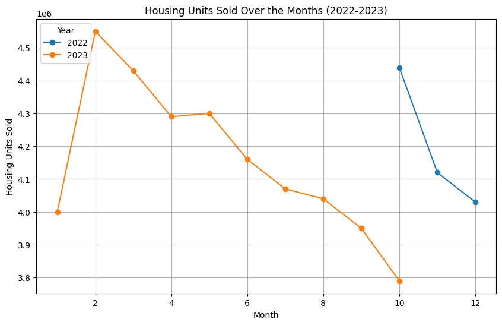

```python
# Plotting
plt.figure(figsize=(10, 6))
for year in Hme_sls['year'].unique():
    year_data = Hme_sls[Hme_sls['year'] == year]
    plt.plot(year_data['month'], year_data['Housing Units Sold'], marker='o', linestyle='-', label=str(year))
plt.title('Housing Units Sold Over the Months (2022-2023)')
plt.xlabel('Month')
plt.ylabel('Housing Units Sold')
plt.grid(True)
plt.legend(title='Year', loc='upper left')  # Add a legend to distinguish the years
plt.show()
```

#### Dhruv

```python
FF_IR
```

|  | date | Federal Funds | year | month |
| --- | --- | --- | --- | --- |
| 0 | 1990-01-01 | 7.97 | 1990 | 1 |
| 1 | 1990-01-02 | 8.54 | 1990 | 1 |
| 2 | 1990-01-03 | 8.37 | 1990 | 1 |
| 3 | 1990-01-04 | 8.29 | 1990 | 1 |
| 4 | 1990-01-05 | 8.20 | 1990 | 1 |
| ... | ... | ... | ... | ... |
| 12383 | 2023-11-27 | 5.33 | 2023 | 11 |
| 12384 | 2023-11-28 | 5.33 | 2023 | 11 |
| 12385 | 2023-11-29 | 5.33 | 2023 | 11 |
| 12386 | 2023-11-30 | 5.33 | 2023 | 11 |
| 12387 | 2023-12-01 | 5.33 | 2023 | 12 |

12388 rows × 4 columns

#### Shiny

```python
R_Prob
```

|  | date | Recession probability | year | month |
| --- | --- | --- | --- | --- |
| 0 | 1990-01-01 | 0.26 | 1990 | 1 |
| 1 | 1990-02-01 | 0.10 | 1990 | 2 |
| 2 | 1990-03-01 | 0.36 | 1990 | 3 |
| 3 | 1990-04-01 | 1.16 | 1990 | 4 |
| 4 | 1990-05-01 | 1.60 | 1990 | 5 |
| ... | ... | ... | ... | ... |
| 401 | 2023-06-01 | 0.38 | 2023 | 6 |
| 402 | 2023-07-01 | 0.10 | 2023 | 7 |
| 403 | 2023-08-01 | 0.14 | 2023 | 8 |
| 404 | 2023-09-01 | 0.36 | 2023 | 9 |
| 405 | 2023-10-01 | 2.22 | 2023 | 10 |

406 rows × 4 columns

### Aggregating the FRED datasets

#### Groupinng the average data according to the year

```python
Hme_sls_group = Hme_sls.groupby('year')['Housing Units Sold'].mean()
Hme_sls_group=Hme_sls_group.to_frame().reset_index()

gb_group=R_Prob.groupby('year')['Recession probability'].mean()
gb_group=gb_group.reset_index()

FF_group=FF_IR.groupby('year')['Federal Funds'].mean()
FF_group=FF_group.reset_index()
```

#### Rishav

```python
Hme_sls_group
```

|  | year | Housing Units Sold |
| --- | --- | --- |
| 0 | 2022 | 4.196667e+06 |
| 1 | 2023 | 4.158000e+06 |

#### Shiny

```python
gb_group
```

|  | year | Recession probability |
| --- | --- | --- |
| 0 | 1990 | 20.931667 |
| 1 | 1991 | 12.460000 |
| 2 | 1992 | 0.101667 |
| 3 | 1993 | 0.115000 |
| 4 | 1994 | 0.008333 |
| 5 | 1995 | 0.153333 |
| 6 | 1996 | 0.085000 |
| 7 | 1997 | 0.015000 |
| 8 | 1998 | 0.090000 |
| 9 | 1999 | 0.030000 |
| 10 | 2000 | 1.780000 |
| 11 | 2001 | 25.935000 |
| 12 | 2002 | 0.881667 |
| 13 | 2003 | 0.321667 |
| 14 | 2004 | 0.133333 |
| 15 | 2005 | 0.958333 |
| 16 | 2006 | 0.101667 |
| 17 | 2007 | 1.120000 |
| 18 | 2008 | 80.221667 |
| 19 | 2009 | 46.610000 |
| 20 | 2010 | 0.070000 |
| 21 | 2011 | 0.091667 |
| 22 | 2012 | 0.143333 |
| 23 | 2013 | 0.060000 |
| 24 | 2014 | 0.051667 |
| 25 | 2015 | 0.773333 |
| 26 | 2016 | 0.248333 |
| 27 | 2017 | 0.086667 |
| 28 | 2018 | 0.166667 |
| 29 | 2019 | 0.613333 |
| 30 | 2020 | 16.728333 |
| 31 | 2021 | 0.101667 |
| 32 | 2022 | 0.416667 |
| 33 | 2023 | 0.394000 |

#### Dhruv

```python
FF_group
```

|  | year | Federal Funds |
| --- | --- | --- |
| 0 | 1990 | 8.096521 |
| 1 | 1991 | 5.685014 |
| 2 | 1992 | 3.521066 |
| 3 | 1993 | 3.021342 |
| 4 | 1994 | 4.206329 |
| 5 | 1995 | 5.834301 |
| 6 | 1996 | 5.300464 |
| 7 | 1997 | 5.461507 |
| 8 | 1998 | 5.350932 |
| 9 | 1999 | 4.972356 |
| 10 | 2000 | 6.237432 |
| 11 | 2001 | 3.878356 |
| 12 | 2002 | 1.666795 |
| 13 | 2003 | 1.126493 |
| 14 | 2004 | 1.350328 |
| 15 | 2005 | 3.217068 |
| 16 | 2006 | 4.965425 |
| 17 | 2007 | 5.017315 |
| 18 | 2008 | 1.924180 |
| 19 | 2009 | 0.158603 |
| 20 | 2010 | 0.176247 |
| 21 | 2011 | 0.101507 |
| 22 | 2012 | 0.140574 |
| 23 | 2013 | 0.107342 |
| 24 | 2014 | 0.088493 |
| 25 | 2015 | 0.133726 |
| 26 | 2016 | 0.393197 |
| 27 | 2017 | 1.002959 |
| 28 | 2018 | 1.834932 |
| 29 | 2019 | 2.157260 |
| 30 | 2020 | 0.372240 |
| 31 | 2021 | 0.078685 |
| 32 | 2022 | 1.692192 |
| 33 | 2023 | 4.998627 |

### Merging the federal funds and recession probablity FRED datasets

```python
#merging the Federal_Funds dataset to the Recession _probability dataset using 'inner'
Fred_1 = FF_group.merge(gb_group,how='inner',on = 'year')
Fred_1
```

|  | year | Federal Funds | Recession probability |
| --- | --- | --- | --- |
| 0 | 1990 | 8.096521 | 20.931667 |
| 1 | 1991 | 5.685014 | 12.460000 |
| 2 | 1992 | 3.521066 | 0.101667 |
| 3 | 1993 | 3.021342 | 0.115000 |
| 4 | 1994 | 4.206329 | 0.008333 |
| 5 | 1995 | 5.834301 | 0.153333 |
| 6 | 1996 | 5.300464 | 0.085000 |
| 7 | 1997 | 5.461507 | 0.015000 |
| 8 | 1998 | 5.350932 | 0.090000 |
| 9 | 1999 | 4.972356 | 0.030000 |
| 10 | 2000 | 6.237432 | 1.780000 |
| 11 | 2001 | 3.878356 | 25.935000 |
| 12 | 2002 | 1.666795 | 0.881667 |
| 13 | 2003 | 1.126493 | 0.321667 |
| 14 | 2004 | 1.350328 | 0.133333 |
| 15 | 2005 | 3.217068 | 0.958333 |
| 16 | 2006 | 4.965425 | 0.101667 |
| 17 | 2007 | 5.017315 | 1.120000 |
| 18 | 2008 | 1.924180 | 80.221667 |
| 19 | 2009 | 0.158603 | 46.610000 |
| 20 | 2010 | 0.176247 | 0.070000 |
| 21 | 2011 | 0.101507 | 0.091667 |
| 22 | 2012 | 0.140574 | 0.143333 |
| 23 | 2013 | 0.107342 | 0.060000 |
| 24 | 2014 | 0.088493 | 0.051667 |
| 25 | 2015 | 0.133726 | 0.773333 |
| 26 | 2016 | 0.393197 | 0.248333 |
| 27 | 2017 | 1.002959 | 0.086667 |
| 28 | 2018 | 1.834932 | 0.166667 |
| 29 | 2019 | 2.157260 | 0.613333 |
| 30 | 2020 | 0.372240 | 16.728333 |
| 31 | 2021 | 0.078685 | 0.101667 |
| 32 | 2022 | 1.692192 | 0.416667 |
| 33 | 2023 | 4.998627 | 0.394000 |

### Inner Merging the *merged*(Federal Funds and Recession Probability) FRED data with the *merged* WRDS data

```python
#merging the Fred_1 dataset obtained above with the WRDS dataset using 'inner'
econ_var_Nat_com_1 = Fred_1.merge(Nat_Comm_Bank,how='inner',on = 'year')
econ_var_Nat_com_1#dataset without the economic variable 'Housing Units Sold'
```

|  | year | Federal Funds | Recession probability | cik | gvkey | datadate | conm | revt | ni | month |
| --- | --- | --- | --- | --- | --- | --- | --- | --- | --- | --- |
| 0 | 1990 | 8.096521 | 20.931667 | 0001045520 | 015581 | 1990-10-31 | CANADIAN IMPERIAL BANK | 13004.736 | 802.447 | 10 |
| 1 | 1990 | 8.096521 | 20.931667 | 0000009631 | 015582 | 1990-10-31 | BANK OF NOVA SCOTIA | 9320.799 | 511.989 | 10 |
| 2 | 1991 | 5.685014 | 12.460000 | 0001045520 | 015581 | 1991-10-31 | CANADIAN IMPERIAL BANK | 12919.748 | 811.204 | 10 |
| 3 | 1991 | 5.685014 | 12.460000 | 0000009631 | 015582 | 1991-10-31 | BANK OF NOVA SCOTIA | 9315.176 | 633.015 | 10 |
| 4 | 1992 | 3.521066 | 0.101667 | 0001045520 | 015581 | 1992-10-31 | CANADIAN IMPERIAL BANK | 11373.000 | 12.000 | 10 |
| ... | ... | ... | ... | ... | ... | ... | ... | ... | ... | ... |
| 10221 | 2023 | 4.998627 | 0.394000 | 0001144967 | 144535 | 2023-03-31 | HDFC BANK LTD | 24921.884 | 5600.999 | 3 |
| 10222 | 2023 | 4.998627 | 0.394000 | 0001538263 | 170419 | 2023-06-30 | HOMETRUST BANCSHARES INC | 218.596 | 44.604 | 6 |
| 10223 | 2023 | 4.998627 | 0.394000 | 0000067088 | 252940 | 2023-03-31 | MITSUBISHI UFJ FINANCIAL GRP | 43244.958 | 4512.706 | 3 |
| 10224 | 2023 | 4.998627 | 0.394000 | 0001335730 | 248136 | 2023-03-31 | MIZUHO FINANCIAL GROUP INC | 37671.024 | 4178.857 | 3 |
| 10225 | 2023 | 4.998627 | 0.394000 | 0001103838 | 223148 | 2023-03-31 | ICICI BANK LTD | 17719.993 | 4144.591 | 3 |

10226 rows × 10 columns

### Inner merging with the housing sales FRED dataset

```python
#merging the econ_var_Nat_com_1 dataset obtained above with the Housing_unites_sold dataset using 'left'
econ_var_Nat_com_merged = pd.merge(econ_var_Nat_com_1, Hme_sls_group, on='year', how='inner')
econ_var_Nat_com_merged#dataset with the economic variable 'Housing Units Sold'
```

|  | year | Federal Funds | Recession probability | cik | gvkey | datadate | conm | revt | ni | month | Housing Units Sold |
| --- | --- | --- | --- | --- | --- | --- | --- | --- | --- | --- | --- |
| 0 | 2022 | 1.692192 | 0.416667 | 0000763901 | 002002 | 2022-12-31 | POPULAR INC | 3096.073 | 1102.641 | 12 | 4.196667e+06 |
| 1 | 2022 | 1.692192 | 0.416667 | 0000046195 | 002005 | 2022-12-31 | BANK OF HAWAII CORP | 754.907 | 225.804 | 12 | 4.196667e+06 |
| 2 | 2022 | 1.692192 | 0.416667 | 0000036146 | 004685 | 2022-12-31 | TRUSTMARK CORP | 746.977 | 71.887 | 12 | 4.196667e+06 |
| 3 | 2022 | 1.692192 | 0.416667 | 0000798941 | 004690 | 2022-12-31 | FIRST CITIZENS BANCSH -CL A | 5105.000 | 1098.000 | 12 | 4.196667e+06 |
| 4 | 2022 | 1.692192 | 0.416667 | 0000019617 | 002968 | 2022-12-31 | JPMORGAN CHASE & CO | 154792.000 | 37676.000 | 12 | 4.196667e+06 |
| ... | ... | ... | ... | ... | ... | ... | ... | ... | ... | ... | ... |
| 480 | 2023 | 4.998627 | 0.394000 | 0001144967 | 144535 | 2023-03-31 | HDFC BANK LTD | 24921.884 | 5600.999 | 3 | 4.158000e+06 |
| 481 | 2023 | 4.998627 | 0.394000 | 0001538263 | 170419 | 2023-06-30 | HOMETRUST BANCSHARES INC | 218.596 | 44.604 | 6 | 4.158000e+06 |
| 482 | 2023 | 4.998627 | 0.394000 | 0000067088 | 252940 | 2023-03-31 | MITSUBISHI UFJ FINANCIAL GRP | 43244.958 | 4512.706 | 3 | 4.158000e+06 |
| 483 | 2023 | 4.998627 | 0.394000 | 0001335730 | 248136 | 2023-03-31 | MIZUHO FINANCIAL GROUP INC | 37671.024 | 4178.857 | 3 | 4.158000e+06 |
| 484 | 2023 | 4.998627 | 0.394000 | 0001103838 | 223148 | 2023-03-31 | ICICI BANK LTD | 17719.993 | 4144.591 | 3 | 4.158000e+06 |

485 rows × 11 columns

```python
econ_var_Nat_com_merged.nunique()
```

```
year                       2
Federal Funds              2
Recession probability      2
cik                      443
gvkey                    465
datadate                   9
conm                     465
revt                     483
ni                       483
month                      5
Housing Units Sold         2
dtype: int64
```

```python
econ_var_Nat_com_merged.info()
```

```
<class 'pandas.core.frame.DataFrame'>
Int64Index: 485 entries, 0 to 484
Data columns (total 11 columns):
 #   Column                 Non-Null Count  Dtype
---  ------                 --------------  -----
 0   year                   485 non-null    int64
 1   Federal Funds          485 non-null    float64
 2   Recession probability  485 non-null    float64
 3   cik                    463 non-null    object
 4   gvkey                  485 non-null    object
 5   datadate               485 non-null    datetime64[ns]
 6   conm                   485 non-null    object
 7   revt                   485 non-null    float64
 8   ni                     485 non-null    float64
 9   month                  485 non-null    int64
 10  Housing Units Sold     485 non-null    float64
dtypes: datetime64[ns](1), float64(5), int64(2), object(3)
memory usage: 45.5+ KB
```

## We have created 2 different datasets:

### - *econ_var_Nat_com_1* : This dataset is formed by 'inner' merging the *Federal Fund* and *Recession Probability* FRED datasets with the WRDS data.

### - *econ_var_Nat_com_merged* : This dataset is formed by 'inner' merging the *Housing Units Sold* FRED dataset with the resulting econ_var_Nat_com_1 data.

## Data Pre-Processing

```python
import pandas as pd
import seaborn as sns
import statsmodels.formula.api as smf
import statsmodels.api as sm
```

### Changing names of few columns since the regression analysis requires a certain naming mechanism for the columns.

```python
# Rename the column
econ_var_Nat_com_1 = econ_var_Nat_com_1.rename(columns={'Federal Funds': 'Federal_Funds'})
econ_var_Nat_com_1 = econ_var_Nat_com_1.rename(columns={'Recession probability': 'Recession_probability'})
econ_var_Nat_com_1
```

|  | year | Federal_Funds | Recession_probability | cik | gvkey | datadate | conm | revt | ni | month |
| --- | --- | --- | --- | --- | --- | --- | --- | --- | --- | --- |
| 0 | 1990 | 8.096521 | 20.931667 | 0001045520 | 015581 | 1990-10-31 | CANADIAN IMPERIAL BANK | 13004.736 | 802.447 | 10 |
| 1 | 1990 | 8.096521 | 20.931667 | 0000009631 | 015582 | 1990-10-31 | BANK OF NOVA SCOTIA | 9320.799 | 511.989 | 10 |
| 2 | 1991 | 5.685014 | 12.460000 | 0001045520 | 015581 | 1991-10-31 | CANADIAN IMPERIAL BANK | 12919.748 | 811.204 | 10 |
| 3 | 1991 | 5.685014 | 12.460000 | 0000009631 | 015582 | 1991-10-31 | BANK OF NOVA SCOTIA | 9315.176 | 633.015 | 10 |
| 4 | 1992 | 3.521066 | 0.101667 | 0001045520 | 015581 | 1992-10-31 | CANADIAN IMPERIAL BANK | 11373.000 | 12.000 | 10 |
| ... | ... | ... | ... | ... | ... | ... | ... | ... | ... | ... |
| 10221 | 2023 | 4.998627 | 0.394000 | 0001144967 | 144535 | 2023-03-31 | HDFC BANK LTD | 24921.884 | 5600.999 | 3 |
| 10222 | 2023 | 4.998627 | 0.394000 | 0001538263 | 170419 | 2023-06-30 | HOMETRUST BANCSHARES INC | 218.596 | 44.604 | 6 |
| 10223 | 2023 | 4.998627 | 0.394000 | 0000067088 | 252940 | 2023-03-31 | MITSUBISHI UFJ FINANCIAL GRP | 43244.958 | 4512.706 | 3 |
| 10224 | 2023 | 4.998627 | 0.394000 | 0001335730 | 248136 | 2023-03-31 | MIZUHO FINANCIAL GROUP INC | 37671.024 | 4178.857 | 3 |
| 10225 | 2023 | 4.998627 | 0.394000 | 0001103838 | 223148 | 2023-03-31 | ICICI BANK LTD | 17719.993 | 4144.591 | 3 |

10226 rows × 10 columns

```python
# Rename the column
econ_var_Nat_com_merged = econ_var_Nat_com_merged.rename(columns={'Housing Units Sold': 'Housing_Units_Sold'})
econ_var_Nat_com_merged = econ_var_Nat_com_merged.rename(columns={'Federal Funds': 'Federal_Funds'})
econ_var_Nat_com_merged = econ_var_Nat_com_merged.rename(columns={'Recession probability': 'Recession_probability'})
econ_var_Nat_com_merged
```

|  | year | Federal_Funds | Recession_probability | cik | gvkey | datadate | conm | revt | ni | month | Housing_Units_Sold |
| --- | --- | --- | --- | --- | --- | --- | --- | --- | --- | --- | --- |
| 0 | 2022 | 1.692192 | 0.416667 | 0000763901 | 002002 | 2022-12-31 | POPULAR INC | 3096.073 | 1102.641 | 12 | 4.196667e+06 |
| 1 | 2022 | 1.692192 | 0.416667 | 0000046195 | 002005 | 2022-12-31 | BANK OF HAWAII CORP | 754.907 | 225.804 | 12 | 4.196667e+06 |
| 2 | 2022 | 1.692192 | 0.416667 | 0000036146 | 004685 | 2022-12-31 | TRUSTMARK CORP | 746.977 | 71.887 | 12 | 4.196667e+06 |
| 3 | 2022 | 1.692192 | 0.416667 | 0000798941 | 004690 | 2022-12-31 | FIRST CITIZENS BANCSH -CL A | 5105.000 | 1098.000 | 12 | 4.196667e+06 |
| 4 | 2022 | 1.692192 | 0.416667 | 0000019617 | 002968 | 2022-12-31 | JPMORGAN CHASE & CO | 154792.000 | 37676.000 | 12 | 4.196667e+06 |
| ... | ... | ... | ... | ... | ... | ... | ... | ... | ... | ... | ... |
| 480 | 2023 | 4.998627 | 0.394000 | 0001144967 | 144535 | 2023-03-31 | HDFC BANK LTD | 24921.884 | 5600.999 | 3 | 4.158000e+06 |
| 481 | 2023 | 4.998627 | 0.394000 | 0001538263 | 170419 | 2023-06-30 | HOMETRUST BANCSHARES INC | 218.596 | 44.604 | 6 | 4.158000e+06 |
| 482 | 2023 | 4.998627 | 0.394000 | 0000067088 | 252940 | 2023-03-31 | MITSUBISHI UFJ FINANCIAL GRP | 43244.958 | 4512.706 | 3 | 4.158000e+06 |
| 483 | 2023 | 4.998627 | 0.394000 | 0001335730 | 248136 | 2023-03-31 | MIZUHO FINANCIAL GROUP INC | 37671.024 | 4178.857 | 3 | 4.158000e+06 |
| 484 | 2023 | 4.998627 | 0.394000 | 0001103838 | 223148 | 2023-03-31 | ICICI BANK LTD | 17719.993 | 4144.591 | 3 | 4.158000e+06 |

485 rows × 11 columns

### Finding the norm and log of revenue for the dataset , because the revenue is very erratically distributed, so to normalize the distribution and stabilizing the variance, we take the log of revenue, which in turn helps with the regression analysis.

```python
econ_var_Nat_com_1['norm'] = (1+econ_var_Nat_com_1.revt)/2
econ_var_Nat_com_1['log_revt'] = np.log(econ_var_Nat_com_1['norm'])
econ_var_Nat_com_1
```

```
C:\Users\Aadiv Das\anaconda3\envs\DataSCience\lib\site-packages\pandas\core\arraylike.py:402: RuntimeWarning: invalid value encountered in log
  result = getattr(ufunc, method)(*inputs, **kwargs)
```

|  | year | Federal_Funds | Recession_probability | cik | gvkey | datadate | conm | revt | ni | month | norm | log_revt |
| --- | --- | --- | --- | --- | --- | --- | --- | --- | --- | --- | --- | --- |
| 0 | 1990 | 8.096521 | 20.931667 | 0001045520 | 015581 | 1990-10-31 | CANADIAN IMPERIAL BANK | 13004.736 | 802.447 | 10 | 6502.8680 | 8.779999 |
| 1 | 1990 | 8.096521 | 20.931667 | 0000009631 | 015582 | 1990-10-31 | BANK OF NOVA SCOTIA | 9320.799 | 511.989 | 10 | 4660.8995 | 8.446964 |
| 2 | 1991 | 5.685014 | 12.460000 | 0001045520 | 015581 | 1991-10-31 | CANADIAN IMPERIAL BANK | 12919.748 | 811.204 | 10 | 6460.3740 | 8.773442 |
| 3 | 1991 | 5.685014 | 12.460000 | 0000009631 | 015582 | 1991-10-31 | BANK OF NOVA SCOTIA | 9315.176 | 633.015 | 10 | 4658.0880 | 8.446360 |
| 4 | 1992 | 3.521066 | 0.101667 | 0001045520 | 015581 | 1992-10-31 | CANADIAN IMPERIAL BANK | 11373.000 | 12.000 | 10 | 5687.0000 | 8.645938 |
| ... | ... | ... | ... | ... | ... | ... | ... | ... | ... | ... | ... | ... |
| 10221 | 2023 | 4.998627 | 0.394000 | 0001144967 | 144535 | 2023-03-31 | HDFC BANK LTD | 24921.884 | 5600.999 | 3 | 12461.4420 | 9.430395 |
| 10222 | 2023 | 4.998627 | 0.394000 | 0001538263 | 170419 | 2023-06-30 | HOMETRUST BANCSHARES INC | 218.596 | 44.604 | 6 | 109.7980 | 4.698642 |
| 10223 | 2023 | 4.998627 | 0.394000 | 0000067088 | 252940 | 2023-03-31 | MITSUBISHI UFJ FINANCIAL GRP | 43244.958 | 4512.706 | 3 | 21622.9790 | 9.981512 |
| 10224 | 2023 | 4.998627 | 0.394000 | 0001335730 | 248136 | 2023-03-31 | MIZUHO FINANCIAL GROUP INC | 37671.024 | 4178.857 | 3 | 18836.0120 | 9.843526 |
| 10225 | 2023 | 4.998627 | 0.394000 | 0001103838 | 223148 | 2023-03-31 | ICICI BANK LTD | 17719.993 | 4144.591 | 3 | 8860.4965 | 9.089358 |

10226 rows × 12 columns

```python
# Apply log1p normalization to the 'revt' column
econ_var_Nat_com_merged['norm'] = (1+econ_var_Nat_com_merged.revt)/2
econ_var_Nat_com_merged['log_revt'] = np.log(econ_var_Nat_com_merged['norm'])
econ_var_Nat_com_merged
```

|  | year | Federal_Funds | Recession_probability | cik | gvkey | datadate | conm | revt | ni | month | Housing_Units_Sold | norm | log_revt |
| --- | --- | --- | --- | --- | --- | --- | --- | --- | --- | --- | --- | --- | --- |
| 0 | 2022 | 1.692192 | 0.416667 | 0000763901 | 002002 | 2022-12-31 | POPULAR INC | 3096.073 | 1102.641 | 12 | 4.196667e+06 | 1548.5365 | 7.345066 |
| 1 | 2022 | 1.692192 | 0.416667 | 0000046195 | 002005 | 2022-12-31 | BANK OF HAWAII CORP | 754.907 | 225.804 | 12 | 4.196667e+06 | 377.9535 | 5.934771 |
| 2 | 2022 | 1.692192 | 0.416667 | 0000036146 | 004685 | 2022-12-31 | TRUSTMARK CORP | 746.977 | 71.887 | 12 | 4.196667e+06 | 373.9885 | 5.924225 |
| 3 | 2022 | 1.692192 | 0.416667 | 0000798941 | 004690 | 2022-12-31 | FIRST CITIZENS BANCSH -CL A | 5105.000 | 1098.000 | 12 | 4.196667e+06 | 2553.0000 | 7.845024 |
| 4 | 2022 | 1.692192 | 0.416667 | 0000019617 | 002968 | 2022-12-31 | JPMORGAN CHASE & CO | 154792.000 | 37676.000 | 12 | 4.196667e+06 | 77396.5000 | 11.256697 |
| ... | ... | ... | ... | ... | ... | ... | ... | ... | ... | ... | ... | ... | ... |
| 480 | 2023 | 4.998627 | 0.394000 | 0001144967 | 144535 | 2023-03-31 | HDFC BANK LTD | 24921.884 | 5600.999 | 3 | 4.158000e+06 | 12461.4420 | 9.430395 |
| 481 | 2023 | 4.998627 | 0.394000 | 0001538263 | 170419 | 2023-06-30 | HOMETRUST BANCSHARES INC | 218.596 | 44.604 | 6 | 4.158000e+06 | 109.7980 | 4.698642 |
| 482 | 2023 | 4.998627 | 0.394000 | 0000067088 | 252940 | 2023-03-31 | MITSUBISHI UFJ FINANCIAL GRP | 43244.958 | 4512.706 | 3 | 4.158000e+06 | 21622.9790 | 9.981512 |
| 483 | 2023 | 4.998627 | 0.394000 | 0001335730 | 248136 | 2023-03-31 | MIZUHO FINANCIAL GROUP INC | 37671.024 | 4178.857 | 3 | 4.158000e+06 | 18836.0120 | 9.843526 |
| 484 | 2023 | 4.998627 | 0.394000 | 0001103838 | 223148 | 2023-03-31 | ICICI BANK LTD | 17719.993 | 4144.591 | 3 | 4.158000e+06 | 8860.4965 | 9.089358 |

485 rows × 13 columns

### Finding the dummy variables on year.:

- **Capturing Year-Specific Effects** , which is particularly useful when there are factors or events unique to certain years that influence the dependent variable.

&

- **Controlling for Time Trends**, where the dummy variables help control for time-related trends or changes in the relationship between variables over different years. This is important when there are systematic shifts in the data that may not be captured by a simple linear trend.

```python
what=pd.get_dummies(econ_var_Nat_com_1['year'], prefix='y')
econ_var_Nat_com_1 = econ_var_Nat_com_1.merge(what, how='inner', left_index=True, right_index=True)
econ_var_Nat_com_1
```

|  | year | Federal_Funds | Recession_probability | cik | gvkey | datadate | conm | revt | ni | month | ... | y_2014 | y_2015 | y_2016 | y_2017 | y_2018 | y_2019 | y_2020 | y_2021 | y_2022 | y_2023 |
| --- | --- | --- | --- | --- | --- | --- | --- | --- | --- | --- | --- | --- | --- | --- | --- | --- | --- | --- | --- | --- | --- |
| 0 | 1990 | 8.096521 | 20.931667 | 0001045520 | 015581 | 1990-10-31 | CANADIAN IMPERIAL BANK | 13004.736 | 802.447 | 10 | ... | 0 | 0 | 0 | 0 | 0 | 0 | 0 | 0 | 0 | 0 |
| 1 | 1990 | 8.096521 | 20.931667 | 0000009631 | 015582 | 1990-10-31 | BANK OF NOVA SCOTIA | 9320.799 | 511.989 | 10 | ... | 0 | 0 | 0 | 0 | 0 | 0 | 0 | 0 | 0 | 0 |
| 2 | 1991 | 5.685014 | 12.460000 | 0001045520 | 015581 | 1991-10-31 | CANADIAN IMPERIAL BANK | 12919.748 | 811.204 | 10 | ... | 0 | 0 | 0 | 0 | 0 | 0 | 0 | 0 | 0 | 0 |
| 3 | 1991 | 5.685014 | 12.460000 | 0000009631 | 015582 | 1991-10-31 | BANK OF NOVA SCOTIA | 9315.176 | 633.015 | 10 | ... | 0 | 0 | 0 | 0 | 0 | 0 | 0 | 0 | 0 | 0 |
| 4 | 1992 | 3.521066 | 0.101667 | 0001045520 | 015581 | 1992-10-31 | CANADIAN IMPERIAL BANK | 11373.000 | 12.000 | 10 | ... | 0 | 0 | 0 | 0 | 0 | 0 | 0 | 0 | 0 | 0 |
| ... | ... | ... | ... | ... | ... | ... | ... | ... | ... | ... | ... | ... | ... | ... | ... | ... | ... | ... | ... | ... | ... |
| 10221 | 2023 | 4.998627 | 0.394000 | 0001144967 | 144535 | 2023-03-31 | HDFC BANK LTD | 24921.884 | 5600.999 | 3 | ... | 0 | 0 | 0 | 0 | 0 | 0 | 0 | 0 | 0 | 1 |
| 10222 | 2023 | 4.998627 | 0.394000 | 0001538263 | 170419 | 2023-06-30 | HOMETRUST BANCSHARES INC | 218.596 | 44.604 | 6 | ... | 0 | 0 | 0 | 0 | 0 | 0 | 0 | 0 | 0 | 1 |
| 10223 | 2023 | 4.998627 | 0.394000 | 0000067088 | 252940 | 2023-03-31 | MITSUBISHI UFJ FINANCIAL GRP | 43244.958 | 4512.706 | 3 | ... | 0 | 0 | 0 | 0 | 0 | 0 | 0 | 0 | 0 | 1 |
| 10224 | 2023 | 4.998627 | 0.394000 | 0001335730 | 248136 | 2023-03-31 | MIZUHO FINANCIAL GROUP INC | 37671.024 | 4178.857 | 3 | ... | 0 | 0 | 0 | 0 | 0 | 0 | 0 | 0 | 0 | 1 |
| 10225 | 2023 | 4.998627 | 0.394000 | 0001103838 | 223148 | 2023-03-31 | ICICI BANK LTD | 17719.993 | 4144.591 | 3 | ... | 0 | 0 | 0 | 0 | 0 | 0 | 0 | 0 | 0 | 1 |

10226 rows × 46 columns

```python
what=pd.get_dummies(econ_var_Nat_com_merged['year'], prefix='y')
econ_var_Nat_com_merged = econ_var_Nat_com_merged.merge(what, how='inner', left_index=True, right_index=True)
econ_var_Nat_com_merged
```

|  | year | Federal_Funds | Recession_probability | cik | gvkey | datadate | conm | revt | ni | month | Housing_Units_Sold | norm | log_revt | y_2022 | y_2023 |
| --- | --- | --- | --- | --- | --- | --- | --- | --- | --- | --- | --- | --- | --- | --- | --- |
| 0 | 2022 | 1.692192 | 0.416667 | 0000763901 | 002002 | 2022-12-31 | POPULAR INC | 3096.073 | 1102.641 | 12 | 4.196667e+06 | 1548.5365 | 7.345066 | 1 | 0 |
| 1 | 2022 | 1.692192 | 0.416667 | 0000046195 | 002005 | 2022-12-31 | BANK OF HAWAII CORP | 754.907 | 225.804 | 12 | 4.196667e+06 | 377.9535 | 5.934771 | 1 | 0 |
| 2 | 2022 | 1.692192 | 0.416667 | 0000036146 | 004685 | 2022-12-31 | TRUSTMARK CORP | 746.977 | 71.887 | 12 | 4.196667e+06 | 373.9885 | 5.924225 | 1 | 0 |
| 3 | 2022 | 1.692192 | 0.416667 | 0000798941 | 004690 | 2022-12-31 | FIRST CITIZENS BANCSH -CL A | 5105.000 | 1098.000 | 12 | 4.196667e+06 | 2553.0000 | 7.845024 | 1 | 0 |
| 4 | 2022 | 1.692192 | 0.416667 | 0000019617 | 002968 | 2022-12-31 | JPMORGAN CHASE & CO | 154792.000 | 37676.000 | 12 | 4.196667e+06 | 77396.5000 | 11.256697 | 1 | 0 |
| ... | ... | ... | ... | ... | ... | ... | ... | ... | ... | ... | ... | ... | ... | ... | ... |
| 480 | 2023 | 4.998627 | 0.394000 | 0001144967 | 144535 | 2023-03-31 | HDFC BANK LTD | 24921.884 | 5600.999 | 3 | 4.158000e+06 | 12461.4420 | 9.430395 | 0 | 1 |
| 481 | 2023 | 4.998627 | 0.394000 | 0001538263 | 170419 | 2023-06-30 | HOMETRUST BANCSHARES INC | 218.596 | 44.604 | 6 | 4.158000e+06 | 109.7980 | 4.698642 | 0 | 1 |
| 482 | 2023 | 4.998627 | 0.394000 | 0000067088 | 252940 | 2023-03-31 | MITSUBISHI UFJ FINANCIAL GRP | 43244.958 | 4512.706 | 3 | 4.158000e+06 | 21622.9790 | 9.981512 | 0 | 1 |
| 483 | 2023 | 4.998627 | 0.394000 | 0001335730 | 248136 | 2023-03-31 | MIZUHO FINANCIAL GROUP INC | 37671.024 | 4178.857 | 3 | 4.158000e+06 | 18836.0120 | 9.843526 | 0 | 1 |
| 484 | 2023 | 4.998627 | 0.394000 | 0001103838 | 223148 | 2023-03-31 | ICICI BANK LTD | 17719.993 | 4144.591 | 3 | 4.158000e+06 | 8860.4965 | 9.089358 | 0 | 1 |

485 rows × 15 columns

## Data Analysis

```python
econ_var_Nat_com_merged['revt'].max()
```

```
154792.0
```

```python
econ_var_Nat_com_merged['revt'].min()
```

```
6.325
```

```python
econ_var_Nat_com_merged['revt'].mean()
```

```
5207.350542268042
```

```python
econ_var_Nat_com_merged['Housing_Units_Sold'].max()
```

```
4196666.666666667
```

```python
econ_var_Nat_com_merged['Housing_Units_Sold'].min()
```

```
4158000.0
```

```python
econ_var_Nat_com_merged['Housing_Units_Sold'].mean()
```

```
4195072.164948452
```

```python
econ_var_Nat_com_merged['Federal_Funds'].max()
```

```
4.998626865671642
```

```python
econ_var_Nat_com_merged['Federal_Funds'].min()
```

```
1.6921917808219178
```

```python
econ_var_Nat_com_merged['Federal_Funds'].mean()
```

```
1.8285396193724226
```

```python
econ_var_Nat_com_merged['Recession_probability'].max()
```

```
0.4166666666666667
```

```python
econ_var_Nat_com_merged['Recession_probability'].min()
```

```
0.394
```

```python
econ_var_Nat_com_merged['Recession_probability'].mean()
```

```
0.41573195876288666
```

```python
econ_var_Nat_com_1['revt'].max()
```

```
154792.0
```

```python
econ_var_Nat_com_1['revt'].min()
```

```
-6749.631
```

```python
econ_var_Nat_com_1['revt'].mean()
```

```
3542.2067302721753
```

```python
econ_var_Nat_com_1['Federal_Funds'].mean()
```

```
1.3711879656448895
```

```python
econ_var_Nat_com_1['Federal_Funds'].max()
```

```
8.096520547945206
```

```python
econ_var_Nat_com_1['Federal_Funds'].min()
```

```
0.07868493150684933
```

```python
econ_var_Nat_com_1['Recession_probability'].mean()
```

```
7.355629115326944
```

```python
econ_var_Nat_com_1['Recession_probability'].max()
```

```
80.22166666666666
```

```python
econ_var_Nat_com_1['Recession_probability'].min()
```

```
0.008333333333333333
```

```python
econ_var_Nat_com_1['gvkey'].nunique()
```

```
963
```